# FOR/STT 875, Exercise 9

7/31/2019

## Learning objectives

- Work with several key `dplyr` functions
- Manipulate data frames (actually tibbles)
- Summarize and visualize data from large data files

## Overview

Modify this R Markdown file by filling in the code needed to answer the questions.

## Submission instructions

Upload your exercise_9.Rmd and exercise_9.html files to the Exercise 9 D2L dropbox.

## Grading

You will receive full credit if your R Markdown document: 1) compiles without error; and 2) correctly completes the `# TODO:` code chunks. Also, please, fill in the feedback questions at the end of the exercise.

## Getting started

Again, set some global options to make the R code printed in the HTML output look nice.

This exercise offers some practice using `dplyr`. The exercise is adapted from the introductory `dplyr` vignette that is available [here](https://cran.r-project.org/web/packages/dplyr/vignettes/dplyr.html).

We’ll use a data frame `flights` that is included in the `nycflights13` package, so load both the `dplyr` and `nycflights13` libraries. **If you haven’t yet installed one or both of these packages, you’ll have to do that first.** In your console window type `install.packages("dplyr")` and `install.packages("nycflights13")` if needed.

Now load the libraries and make the nycflights13 data available.

```r
library(dplyr)
library(nycflights13)
```

First let’s look at the data frame `flights`. The following would be dangerous if `nycflights13` were an ordinary data frame (because all 336776 rows and 19 columns would be printed to your screen), but it is a `tbl_df` object which has more intelligent (although sometimes irritating) display options.

```r
flights
```

```
# A tibble: 336,776 x 19
    year month   day dep_time sched_dep_time dep_delay arr_time
   <int> <int> <int>    <int>          <int>     <dbl>    <int>
 1  2013     1     1      517            515         2      830
 2  2013     1     1      533            529         4      850
 3  2013     1     1      542            540         2      923
 4  2013     1     1      544            545        -1     1004
 5  2013     1     1      554            600        -6      812
 6  2013     1     1      554            558        -4      740
 7  2013     1     1      555            600        -5      913
 8  2013     1     1      557            600        -3      709
 9  2013     1     1      557            600        -3      838
10  2013     1     1      558            600        -2      753
# … with 336,766 more rows, and 12 more variables: sched_arr_time <int>,
#   arr_delay <dbl>, carrier <chr>, flight <int>, tailnum <chr>,
#   origin <chr>, dest <chr>, air_time <dbl>, distance <dbl>, hour <dbl>,
#   minute <dbl>, time_hour <dttm>
```

##`print` and `glimpse`  
What if we wanted to see more (or less) than 10 rows of `flights` or wanted to see all the variables? To specify the number of rows displayed we can use a print statement, and specify the number of rows:

```r
print(flights, n = 20)
```

```
# A tibble: 336,776 x 19
    year month   day dep_time sched_dep_time dep_delay arr_time
   <int> <int> <int>    <int>          <int>     <dbl>    <int>
 1  2013     1     1      517            515         2      830
 2  2013     1     1      533            529         4      850
 3  2013     1     1      542            540         2      923
 4  2013     1     1      544            545        -1     1004
 5  2013     1     1      554            600        -6      812
 6  2013     1     1      554            558        -4      740
 7  2013     1     1      555            600        -5      913
 8  2013     1     1      557            600        -3      709
 9  2013     1     1      557            600        -3      838
10  2013     1     1      558            600        -2      753
11  2013     1     1      558            600        -2      849
12  2013     1     1      558            600        -2      853
13  2013     1     1      558            600        -2      924
14  2013     1     1      558            600        -2      923
15  2013     1     1      559            600        -1      941
16  2013     1     1      559            559         0      702
17  2013     1     1      559            600        -1      854
18  2013     1     1      600            600         0      851
19  2013     1     1      600            600         0      837
20  2013     1     1      601            600         1      844
# … with 3.368e+05 more rows, and 12 more variables: sched_arr_time <int>,
#   arr_delay <dbl>, carrier <chr>, flight <int>, tailnum <chr>,
#   origin <chr>, dest <chr>, air_time <dbl>, distance <dbl>, hour <dbl>,
#   minute <dbl>, time_hour <dttm>
```

To see all the variables, use `glimpse`.

```r
glimpse(flights)
```

```
Observations: 336,776
Variables: 19
$ year           <int> 2013, 2013, 2013, 2013, 2013, 2013, 2013, 2013, 2…
$ month          <int> 1, 1, 1, 1, 1, 1, 1, 1, 1, 1, 1, 1, 1, 1, 1, 1, 1…
$ day            <int> 1, 1, 1, 1, 1, 1, 1, 1, 1, 1, 1, 1, 1, 1, 1, 1, 1…
$ dep_time       <int> 517, 533, 542, 544, 554, 554, 555, 557, 557, 558,…
$ sched_dep_time <int> 515, 529, 540, 545, 600, 558, 600, 600, 600, 600,…
$ dep_delay      <dbl> 2, 4, 2, -1, -6, -4, -5, -3, -3, -2, -2, -2, -2, …
$ arr_time       <int> 830, 850, 923, 1004, 812, 740, 913, 709, 838, 753…
$ sched_arr_time <int> 819, 830, 850, 1022, 837, 728, 854, 723, 846, 745…
$ arr_delay      <dbl> 11, 20, 33, -18, -25, 12, 19, -14, -8, 8, -2, -3,…
$ carrier        <chr> "UA", "UA", "AA", "B6", "DL", "UA", "B6", "EV", "…
$ flight         <int> 1545, 1714, 1141, 725, 461, 1696, 507, 5708, 79, …
$ tailnum        <chr> "N14228", "N24211", "N619AA", "N804JB", "N668DN",…
$ origin         <chr> "EWR", "LGA", "JFK", "JFK", "LGA", "EWR", "EWR", …
$ dest           <chr> "IAH", "IAH", "MIA", "BQN", "ATL", "ORD", "FLL", …
$ air_time       <dbl> 227, 227, 160, 183, 116, 150, 158, 53, 140, 138, …
$ distance       <dbl> 1400, 1416, 1089, 1576, 762, 719, 1065, 229, 944,…
$ hour           <dbl> 5, 5, 5, 5, 6, 5, 6, 6, 6, 6, 6, 6, 6, 6, 6, 5, 6…
$ minute         <dbl> 15, 29, 40, 45, 0, 58, 0, 0, 0, 0, 0, 0, 0, 0, 0,…
$ time_hour      <dttm> 2013-01-01 05:00:00, 2013-01-01 05:00:00, 2013-0…
```

##`filter`, `slice`, and `arrange`  
The `filter` function filters rows based on specified criteria. It is similar to the `subset` function in base R. For example here we select flights from March that had Detroit Metro Airport as their destination.

```r
filter(flights, month == 3 & dest == "DTW")
```

```
# A tibble: 775 x 19
    year month   day dep_time sched_dep_time dep_delay arr_time
   <int> <int> <int>    <int>          <int>     <dbl>    <int>
 1  2013     3     1      550            600       -10      747
 2  2013     3     1      558            600        -2      750
 3  2013     3     1      558            605        -7      803
 4  2013     3     1      719            720        -1      908
 5  2013     3     1      743            735         8      932
 6  2013     3     1      838            837         1     1051
 7  2013     3     1      849            855        -6     1053
 8  2013     3     1      903            900         3     1120
 9  2013     3     1      903            905        -2     1125
10  2013     3     1     1024           1029        -5     1205
# … with 765 more rows, and 12 more variables: sched_arr_time <int>,
#   arr_delay <dbl>, carrier <chr>, flight <int>, tailnum <chr>,
#   origin <chr>, dest <chr>, air_time <dbl>, distance <dbl>, hour <dbl>,
#   minute <dbl>, time_hour <dttm>
```

Which flights in January have either Detroit Metro (DTW) or Chicago O’Hare (ORD) destinations?

```r
## TODO 9.1: January flights to Detroit Metro (DTW) or Chicago O'Hare (ORD)
filter(flights, month == 1 & (dest == "DTW" | dest == "ORD"))
```

```
# A tibble: 2,056 x 19
    year month   day dep_time sched_dep_time dep_delay arr_time
   <int> <int> <int>    <int>          <int>     <dbl>    <int>
 1  2013     1     1      554            558        -4      740
 2  2013     1     1      558            600        -2      753
 3  2013     1     1      602            605        -3      821
 4  2013     1     1      608            600         8      807
 5  2013     1     1      629            630        -1      824
 6  2013     1     1      656            700        -4      854
 7  2013     1     1      659            705        -6      907
 8  2013     1     1      709            700         9      852
 9  2013     1     1      715            713         2      911
10  2013     1     1      739            745        -6      918
# … with 2,046 more rows, and 12 more variables: sched_arr_time <int>,
#   arr_delay <dbl>, carrier <chr>, flight <int>, tailnum <chr>,
#   origin <chr>, dest <chr>, air_time <dbl>, distance <dbl>, hour <dbl>,
#   minute <dbl>, time_hour <dttm>
```

```r
# or
filter(flights, month == 1 & dest %in% c("DTW", "ORD"))
```

```
# A tibble: 2,056 x 19
    year month   day dep_time sched_dep_time dep_delay arr_time
   <int> <int> <int>    <int>          <int>     <dbl>    <int>
 1  2013     1     1      554            558        -4      740
 2  2013     1     1      558            600        -2      753
 3  2013     1     1      602            605        -3      821
 4  2013     1     1      608            600         8      807
 5  2013     1     1      629            630        -1      824
 6  2013     1     1      656            700        -4      854
 7  2013     1     1      659            705        -6      907
 8  2013     1     1      709            700         9      852
 9  2013     1     1      715            713         2      911
10  2013     1     1      739            745        -6      918
# … with 2,046 more rows, and 12 more variables: sched_arr_time <int>,
#   arr_delay <dbl>, carrier <chr>, flight <int>, tailnum <chr>,
#   origin <chr>, dest <chr>, air_time <dbl>, distance <dbl>, hour <dbl>,
#   minute <dbl>, time_hour <dttm>
```

The `slice` function selects specified rows. To select the first, third, seventh, and twentieth rows:

```r
slice(flights, c(1, 3, 7, 20))
```

```
# A tibble: 4 x 19
   year month   day dep_time sched_dep_time dep_delay arr_time
  <int> <int> <int>    <int>          <int>     <dbl>    <int>
1  2013     1     1      517            515         2      830
2  2013     1     1      542            540         2      923
3  2013     1     1      555            600        -5      913
4  2013     1     1      601            600         1      844
# … with 12 more variables: sched_arr_time <int>, arr_delay <dbl>,
#   carrier <chr>, flight <int>, tailnum <chr>, origin <chr>, dest <chr>,
#   air_time <dbl>, distance <dbl>, hour <dbl>, minute <dbl>,
#   time_hour <dttm>
```

The `arrange` function reorders rows. For example here we order the data set first by arrival time and then by carrier.

```r
arrange(flights, arr_time, carrier)
```

```
# A tibble: 336,776 x 19
    year month   day dep_time sched_dep_time dep_delay arr_time
   <int> <int> <int>    <int>          <int>     <dbl>    <int>
 1  2013    12    15     2155           2100        55        1
 2  2013     5    10     2051           1955        56        1
 3  2013     6    25     2112           1830       162        1
 4  2013     7    19     2059           2030        29        1
 5  2013    12    22     2052           1930        82        1
 6  2013     2    11     2119           1955        84        1
 7  2013     6    25     2056           1755       181        1
 8  2013     7     6     2149           2150        -1        1
 9  2013     1     2     2130           2130         0        1
10  2013     1    11     2253           2249         4        1
# … with 336,766 more rows, and 12 more variables: sched_arr_time <int>,
#   arr_delay <dbl>, carrier <chr>, flight <int>, tailnum <chr>,
#   origin <chr>, dest <chr>, air_time <dbl>, distance <dbl>, hour <dbl>,
#   minute <dbl>, time_hour <dttm>
```

Arrange flights by distance (`distance`) and then by departure delay (`dep_delay`), with the sorting being in descending order in both cases? (You’ll find the `desc` function useful in conjunction with `arrange`.)

```r
# TODO 9.2: arrange flights by distance and then by departure delay, with
# the sorting being in descending order in both cases
flights %>% arrange(desc(distance), desc(dep_delay))
```

```
# A tibble: 336,776 x 19
    year month   day dep_time sched_dep_time dep_delay arr_time
   <int> <int> <int>    <int>          <int>     <dbl>    <int>
 1  2013     1     9      641            900      1301     1242
 2  2013     2    23     1226            900       206     1746
 3  2013     2     9     1206            900       186     1814
 4  2013     8    25     1214           1000       134     1645
 5  2013     1    18     1103            900       123     1635
 6  2013     6    13     1153           1000       113     1649
 7  2013     1     7     1042            900       102     1620
 8  2013     1    23     1041            900       101     1652
 9  2013     7     7     1128           1000        88     1553
10  2013     1     6     1019            900        79     1558
# … with 336,766 more rows, and 12 more variables: sched_arr_time <int>,
#   arr_delay <dbl>, carrier <chr>, flight <int>, tailnum <chr>,
#   origin <chr>, dest <chr>, air_time <dbl>, distance <dbl>, hour <dbl>,
#   minute <dbl>, time_hour <dttm>
```

```r
# or
print(select(arrange(flights, desc(distance), desc(dep_delay)), distance, dep_delay))
```

```
# A tibble: 336,776 x 2
   distance dep_delay
      <dbl>     <dbl>
 1     4983      1301
 2     4983       206
 3     4983       186
 4     4983       134
 5     4983       123
 6     4983       113
 7     4983       102
 8     4983       101
 9     4983        88
10     4983        79
# … with 336,766 more rows
```

*TODO 9.3*: In your output above, what happens to `dep_delay` when `distance` changes from one distance to the next smallest? Add your answer here.

*Answer*: At page 35, row 342 has smallest `dap_delay`(-16) for first and the largest `distance` (4983). The next smallest `distance`(4963) starts from row 343 has the largest `dep_daly`(290) for `distance`(4963). Same for the next smallest that the `dep_delay` has decreasing sorts for each `distance` thus always starts from the largest `dep_delay` for each `distance`.

##`select`, `mutate`, and `summarize`  
The `select`, `mutate`, and `summarize` functions work with columns. To choose a subset of the existing columns, use `select`. It is also possible to rename variables when using `select`. Here are two examples.

```r
select(flights, month, origin, dest)
```

```
# A tibble: 336,776 x 3
   month origin dest
   <int> <chr>  <chr>
 1     1 EWR    IAH
 2     1 LGA    IAH
 3     1 JFK    MIA
 4     1 JFK    BQN
 5     1 LGA    ATL
 6     1 EWR    ORD
 7     1 EWR    FLL
 8     1 LGA    IAD
 9     1 JFK    MCO
10     1 LGA    ORD
# … with 336,766 more rows
```

```r
select(flights, month, origin, destination = dest)
```

```
# A tibble: 336,776 x 3
   month origin destination
   <int> <chr>  <chr>
 1     1 EWR    IAH
 2     1 LGA    IAH
 3     1 JFK    MIA
 4     1 JFK    BQN
 5     1 LGA    ATL
 6     1 EWR    ORD
 7     1 EWR    FLL
 8     1 LGA    IAD
 9     1 JFK    MCO
10     1 LGA    ORD
# … with 336,766 more rows
```

Columns to be selected can also be specified using `start:end` to specify all columns from the column named `start` to the column named `end`. In addition a minus sign before the specified columns indicates that all except those columns should be selected.

Use select to return a data frame with the variables representing departure time, departure delay, arrival time, arrival delay, origin, and destination.

```r
## TODO 9.4: Select the columns here
select(flights, departureTime = dep_time, departureDelay = dep_delay, arrivalTime = arr_time,
    arrivalDelay = arr_delay, origin, destination = dest)
```

```
# A tibble: 336,776 x 6
   departureTime departureDelay arrivalTime arrivalDelay origin destination
           <int>          <dbl>       <int>        <dbl> <chr>  <chr>
 1           517              2         830           11 EWR    IAH
 2           533              4         850           20 LGA    IAH
 3           542              2         923           33 JFK    MIA
 4           544             -1        1004          -18 JFK    BQN
 5           554             -6         812          -25 LGA    ATL
 6           554             -4         740           12 EWR    ORD
 7           555             -5         913           19 EWR    FLL
 8           557             -3         709          -14 LGA    IAD
 9           557             -3         838           -8 JFK    MCO
10           558             -2         753            8 LGA    ORD
# … with 336,766 more rows
```

The `mutate` function provides a simple way to create new columns that are functions of existing columns.

```r
glimpse(mutate(flights, gain = arr_delay - dep_delay, speed = distance/air_time *
    60))
```

```
Observations: 336,776
Variables: 21
$ year           <int> 2013, 2013, 2013, 2013, 2013, 2013, 2013, 2013, 2…
$ month          <int> 1, 1, 1, 1, 1, 1, 1, 1, 1, 1, 1, 1, 1, 1, 1, 1, 1…
$ day            <int> 1, 1, 1, 1, 1, 1, 1, 1, 1, 1, 1, 1, 1, 1, 1, 1, 1…
$ dep_time       <int> 517, 533, 542, 544, 554, 554, 555, 557, 557, 558,…
$ sched_dep_time <int> 515, 529, 540, 545, 600, 558, 600, 600, 600, 600,…
$ dep_delay      <dbl> 2, 4, 2, -1, -6, -4, -5, -3, -3, -2, -2, -2, -2, …
$ arr_time       <int> 830, 850, 923, 1004, 812, 740, 913, 709, 838, 753…
$ sched_arr_time <int> 819, 830, 850, 1022, 837, 728, 854, 723, 846, 745…
$ arr_delay      <dbl> 11, 20, 33, -18, -25, 12, 19, -14, -8, 8, -2, -3,…
$ carrier        <chr> "UA", "UA", "AA", "B6", "DL", "UA", "B6", "EV", "…
$ flight         <int> 1545, 1714, 1141, 725, 461, 1696, 507, 5708, 79, …
$ tailnum        <chr> "N14228", "N24211", "N619AA", "N804JB", "N668DN",…
$ origin         <chr> "EWR", "LGA", "JFK", "JFK", "LGA", "EWR", "EWR", …
$ dest           <chr> "IAH", "IAH", "MIA", "BQN", "ATL", "ORD", "FLL", …
$ air_time       <dbl> 227, 227, 160, 183, 116, 150, 158, 53, 140, 138, …
$ distance       <dbl> 1400, 1416, 1089, 1576, 762, 719, 1065, 229, 944,…
$ hour           <dbl> 5, 5, 5, 5, 6, 5, 6, 6, 6, 6, 6, 6, 6, 6, 6, 5, 6…
$ minute         <dbl> 15, 29, 40, 45, 0, 58, 0, 0, 0, 0, 0, 0, 0, 0, 0,…
$ time_hour      <dttm> 2013-01-01 05:00:00, 2013-01-01 05:00:00, 2013-0…
$ gain           <dbl> 9, 16, 31, -17, -19, 16, 24, -11, -5, 10, 0, -1, …
$ speed          <dbl> 370.0441, 374.2731, 408.3750, 516.7213, 394.1379,…
```

Create two new columns, one called `total_gain` (calculated as `gain` in the `mutate` call above), and another which has the gain per hour, i.e., `total_gain` divided by the `(air_time/60)`.

```r
# TODO 9.5: Create the new columns here
glimpse(mutate(flights, total_gain = arr_delay - dep_delay, gain_per_hour = total_gain/(air_time/60)))
```

```
Observations: 336,776
Variables: 21
$ year           <int> 2013, 2013, 2013, 2013, 2013, 2013, 2013, 2013, 2…
$ month          <int> 1, 1, 1, 1, 1, 1, 1, 1, 1, 1, 1, 1, 1, 1, 1, 1, 1…
$ day            <int> 1, 1, 1, 1, 1, 1, 1, 1, 1, 1, 1, 1, 1, 1, 1, 1, 1…
$ dep_time       <int> 517, 533, 542, 544, 554, 554, 555, 557, 557, 558,…
$ sched_dep_time <int> 515, 529, 540, 545, 600, 558, 600, 600, 600, 600,…
$ dep_delay      <dbl> 2, 4, 2, -1, -6, -4, -5, -3, -3, -2, -2, -2, -2, …
$ arr_time       <int> 830, 850, 923, 1004, 812, 740, 913, 709, 838, 753…
$ sched_arr_time <int> 819, 830, 850, 1022, 837, 728, 854, 723, 846, 745…
$ arr_delay      <dbl> 11, 20, 33, -18, -25, 12, 19, -14, -8, 8, -2, -3,…
$ carrier        <chr> "UA", "UA", "AA", "B6", "DL", "UA", "B6", "EV", "…
$ flight         <int> 1545, 1714, 1141, 725, 461, 1696, 507, 5708, 79, …
$ tailnum        <chr> "N14228", "N24211", "N619AA", "N804JB", "N668DN",…
$ origin         <chr> "EWR", "LGA", "JFK", "JFK", "LGA", "EWR", "EWR", …
$ dest           <chr> "IAH", "IAH", "MIA", "BQN", "ATL", "ORD", "FLL", …
$ air_time       <dbl> 227, 227, 160, 183, 116, 150, 158, 53, 140, 138, …
$ distance       <dbl> 1400, 1416, 1089, 1576, 762, 719, 1065, 229, 944,…
$ hour           <dbl> 5, 5, 5, 5, 6, 5, 6, 6, 6, 6, 6, 6, 6, 6, 6, 5, 6…
$ minute         <dbl> 15, 29, 40, 45, 0, 58, 0, 0, 0, 0, 0, 0, 0, 0, 0,…
$ time_hour      <dttm> 2013-01-01 05:00:00, 2013-01-01 05:00:00, 2013-0…
$ total_gain     <dbl> 9, 16, 31, -17, -19, 16, 24, -11, -5, 10, 0, -1, …
$ gain_per_hour  <dbl> 2.3788546, 4.2290749, 11.6250000, -5.5737705, -9.…
```

The `summarize` (or `summarise`) function returns a function of one or more columns.

```r
summarise(flights, mean_dep_delay = mean(dep_delay, na.rm = TRUE), mean_arr_delay = mean(arr_delay,
    na.rm = TRUE))
```

```
# A tibble: 1 x 2
  mean_dep_delay mean_arr_delay
           <dbl>          <dbl>
1           12.6           6.90
```

We’ll see the real power of `summarize` when we pair it with `dplyr`’s grouping capabilities.

##`group_by` and `%>%`  
Grouping operations add substantially to the power of the `dplyr` functions. We will focus on using `summarize` with grouping, but grouping also can be used with other functions. (This is akin to using `tapply` but the syntax and power are much better.) Often we apply several functions in order. The piping operator `%>%` improves both readability and intuitiveness of these more complex operations.

Here are three different ways to compute the number of flights, the mean distance of flights, and the mean arrival delay of flights, for each month of the year. In the first, we create an intermediate data frame with grouping. In the second, we nest functions. In the third, we use the piping operator.

```r
flights_by_month <- group_by(flights, month)
summarize(flights_by_month, number = n(), mean_distance = mean(distance, na.rm = TRUE),
    mean_arrival_delay = mean(arr_delay, na.rm = TRUE))
```

```
# A tibble: 12 x 4
   month number mean_distance mean_arrival_delay
   <int>  <int>         <dbl>              <dbl>
 1     1  27004         1007.              6.13
 2     2  24951         1001.              5.61
 3     3  28834         1012.              5.81
 4     4  28330         1039.             11.2
 5     5  28796         1041.              3.52
 6     6  28243         1057.             16.5
 7     7  29425         1059.             16.7
 8     8  29327         1062.              6.04
 9     9  27574         1041.             -4.02
10    10  28889         1039.             -0.167
11    11  27268         1050.              0.461
12    12  28135         1065.             14.9
```

```r
summarize(group_by(flights, month), number = n(), mean_distance = mean(distance,
    na.rm = TRUE), mean_arrival_delay = mean(arr_delay, na.rm = TRUE))
```

```
# A tibble: 12 x 4
   month number mean_distance mean_arrival_delay
   <int>  <int>         <dbl>              <dbl>
 1     1  27004         1007.              6.13
 2     2  24951         1001.              5.61
 3     3  28834         1012.              5.81
 4     4  28330         1039.             11.2
 5     5  28796         1041.              3.52
 6     6  28243         1057.             16.5
 7     7  29425         1059.             16.7
 8     8  29327         1062.              6.04
 9     9  27574         1041.             -4.02
10    10  28889         1039.             -0.167
11    11  27268         1050.              0.461
12    12  28135         1065.             14.9
```

```r
group_by(flights, month) %>% summarize(number = n(), mean_distance = mean(distance,
    na.rm = TRUE), mean_arrival_delay = mean(arr_delay, na.rm = TRUE))
```

```
# A tibble: 12 x 4
   month number mean_distance mean_arrival_delay
   <int>  <int>         <dbl>              <dbl>
 1     1  27004         1007.              6.13
 2     2  24951         1001.              5.61
 3     3  28834         1012.              5.81
 4     4  28330         1039.             11.2
 5     5  28796         1041.              3.52
 6     6  28243         1057.             16.5
 7     7  29425         1059.             16.7
 8     8  29327         1062.              6.04
 9     9  27574         1041.             -4.02
10    10  28889         1039.             -0.167
11    11  27268         1050.              0.461
12    12  28135         1065.             14.9
```

We can even pipe the results into the `ggplot` function to produce a scatter plot. Of course if we planned to do a lot of exploration we might want to save the results first and then construct the plot, as in the second section below.

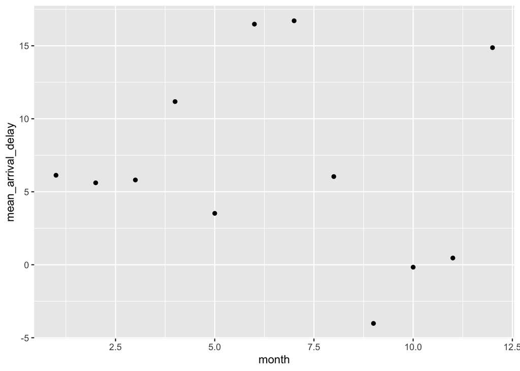

```r
## Pipe the results directly into ggplot
library(ggplot2)
group_by(flights, month) %>% summarize(number = n(), mean_distance = mean(distance,
    na.rm = TRUE), mean_arrival_delay = mean(arr_delay, na.rm = TRUE)) %>% ggplot(aes(x = month,
    y = mean_arrival_delay)) + geom_point()
```

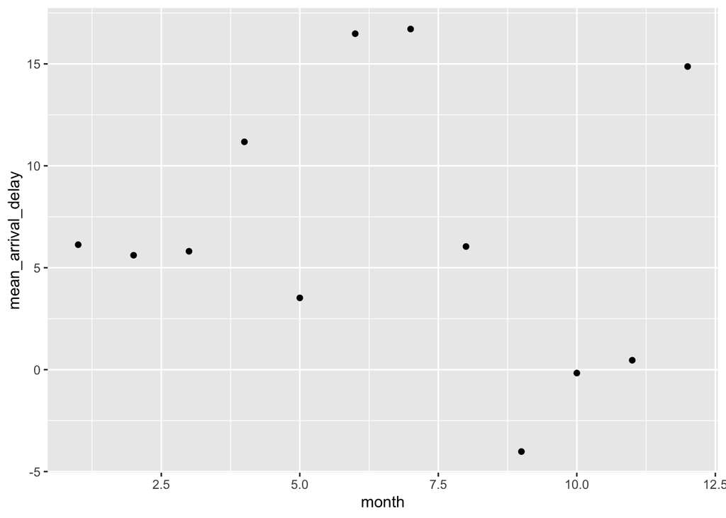

```r
## Save the results in 'delays' and then use ggplot on delays
delays <- group_by(flights, month) %>% summarize(number = n(), mean_distance = mean(distance,
    na.rm = TRUE), mean_arrival_delay = mean(arr_delay, na.rm = TRUE))
ggplot(data = delays, aes(x = month, y = mean_arrival_delay)) + geom_point()
```

Create a data frame that gives the number of flights and the mean arrival delay for flights on the carrier UA (United Airlines) whose destination is O’Hare Airport (ORD), with the number of flights and mean arrival delay calculated separately for flights out of each of the `origin` airports. (Hint: You’ll probably want to use `filter` first to get the UA flights whose destination is ORD, then group by the originating airport, then calculate the statistics requested.)

```r
## TODO 9.6: add code here to answer the query above
filter(flights, carrier == "UA" & dest == "ORD") %>% group_by(origin) %>% summarise(number = n(),
    mean_arrival_delay = mean(arr_delay, na.rm = TRUE))
```

```
# A tibble: 2 x 3
  origin number mean_arrival_delay
  <chr>   <int>              <dbl>
1 EWR      3822               4.88
2 LGA      3162               7.53
```

Congratulations! You’ve reached the end of Exercise 9.

###Questions?

If you have any lingering questions about the material in this document or in the corresponding chapter, put them here.

*In TODO 9.2, I tried code `flights %>% arrange(desc(distance, dep_delay))` at first. The results didn’t arrange by descreasing of dep_delay but only by the distance. Then I change to the format I had now which has both the correct orders. But I’m still curious what’s the meaning of this code?*

###Give us your feedback!

1. How do you feel you’re doing in this class?

*I really learnt a lot from this class and really like it..*

2. What could be done to improve your learning experience?

*Since the book is really helpful, the homework could depend more on what’s in the book.*